# **Unlocking Organic Growth Opportunities at Regork**

# **Introduction**

Regork has identified organic products as a high-value growth opportunity within its product portfolio. Organic items not only generate strong margins for the company, but also align with increasing consumer interest in healthier and more sustainable food choices. As demand for wellness-oriented products continues to rise, understanding how to expand organic purchasing behavior becomes a strategic priority.

The central business question guiding this analysis is: How can Regork increase customer purchases of organic products? To answer this, our team examined three key dimensions of organic purchasing behavior: who to target, when to target them, and which promotional strategies are most effective.

Using transaction, demographic, and promotion data, we analyzed customer segments, seasonal patterns, co-purchase behaviors, and the effectiveness of different types of discounts. By identifying the right customer segments, optimal timing, and most impactful promotional tactics, this report aims to provide data-driven recommendations that will increase organic sales while strengthening long-term customer loyalty.

Ultimately, our goal is to help Regork strategically position organic products in a way that drives sustainable revenue growth while encouraging healthier purchasing habits among its customers.

# **Importing Packages and Data Preparation**

```python
pip install completejourney_py
```

```python
import completejourney_py as cj
```

```python
import pandas as pd
import matplotlib.pyplot as plt
import seaborn as sns
```

```python
from completejourney_py import get_data

cj_data = get_data()
transactions = cj_data['transactions']
demographics = cj_data['demographics']
products = cj_data['products']
campaigns = cj_data['campaigns']
households = cj_data['demographics']
```

```python
products['is_organic'] = products['product_category'].fillna('').str.contains('ORGANIC', case=False) | \
                           products['product_type'].fillna('').str.contains('ORGANIC', case=False)
```

# **Visualizations**

**Who buys organic products?**

```python
merged_df = transactions.merge(products, on='product_id', how='left')
organic_products_df = merged_df[merged_df['is_organic'] == True]
organic_products_with_demographics = organic_products_df.merge(households, on='household_id', how='left')

def categorize_income(income_str):
    if 'Under 15K' in income_str or '15-24K' in income_str or '25-34K' in income_str:
        return 'Low Income'
    elif '35-49K' in income_str or '50-74K' in income_str or '75-99K' in income_str:
        return 'Middle Income'
    elif '100-124K' in income_str or '125-149K' in income_str or \
         '150-174K' in income_str or '175-199K' in income_str or \
         '200-250K' in income_str or '250K+' in income_str:
        return 'High Income'
    return 'Unknown'

organic_products_with_demographics['income_category'] = organic_products_with_demographics['income'].fillna('Unknown').apply(categorize_income)

organic_sales_by_category = organic_products_with_demographics.groupby('income_category').agg(
    {'sales_value': 'sum', 'household_id': 'nunique'}
).rename(columns={'sales_value': 'Total Sales Value', 'household_id': 'Unique Households'})

organic_sales_by_category.index.name = 'Income Category'

organic_sales_by_category_filtered = organic_sales_by_category[organic_sales_by_category.index !='Unknown']
print(organic_sales_by_category_filtered)
```

```
                 Total Sales Value  Unique Households
Income Category
High Income                2430.39                 99
Low Income                 1005.56                100
Middle Income              3769.93                266
```

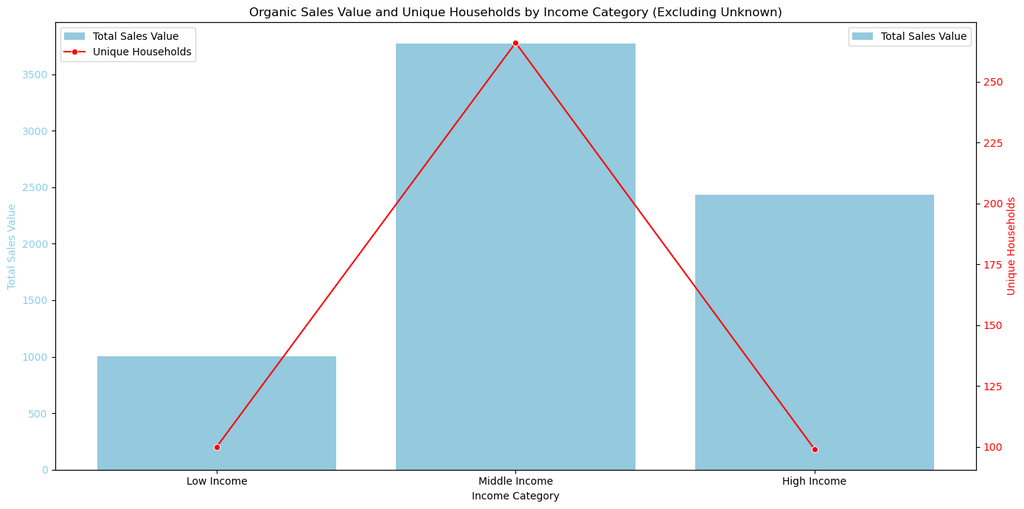

```python
import matplotlib.pyplot as plt
import seaborn as sns

# Define the desired order for income categories
income_order = ['Low Income', 'Middle Income', 'High Income']

# Reindex the DataFrame to ensure the desired order
organic_sales_by_category_filtered = organic_sales_by_category_filtered.reindex(income_order)

fig, ax1 = plt.subplots(figsize=(14, 7))

# Plot Total Sales Value
sns.barplot(x=organic_sales_by_category_filtered.index, y='Total Sales Value', data=organic_sales_by_category_filtered, ax=ax1, color='skyblue', label='Total Sales Value')
ax1.set_xlabel('Income Category')
ax1.set_ylabel('Total Sales Value', color='skyblue')
ax1.tick_params(axis='y', labelcolor='skyblue')
ax1.tick_params(axis='x', rotation=0)

# Create a second y-axis for Unique Households
ax2 = ax1.twinx()
sns.lineplot(x=organic_sales_by_category_filtered.index, y='Unique Households', data=organic_sales_by_category_filtered, ax=ax2, color='red', marker='o', label='Unique Households')
ax2.set_ylabel('Unique Households', color='red')
ax2.tick_params(axis='y', labelcolor='red')

# Add title and legends
plt.title('Organic Sales Value and Unique Households by Income Category (Excluding Unknown)')

# Combine legends
lines, labels = ax1.get_legend_handles_labels()
lines2, labels2 = ax2.get_legend_handles_labels()
ax2.legend(lines + lines2, labels + labels2, loc='upper left')

plt.tight_layout()
plt.show()
```

**Summary of findings**

The chart clearly illustrates that the middle income housholds buy the most organic products. This indicates that we should target this demographic to create more value for the company and help increase the sales of organic products.

**Organic products based on time of the year and income**

**Monthly Organic Sales Trend**

To examine whether organic purchasing behavior changes throughout the year, we aggregated total organic sales by month. This allows us to observe overall seasonality patterns and identify fluctuations in organic demand across the calendar year

```python
import altair as alt
print("Altair imported successfully.")
```

```
Altair imported successfully.
```

```python
merged_transactions_products = transactions.merge(products, on='product_id', how='left')
organic_transactions = merged_transactions_products[merged_transactions_products['is_organic'] == True].copy()

organic_transactions['transaction_timestamp'] = pd.to_datetime(organic_transactions['transaction_timestamp'])
organic_transactions['month'] = organic_transactions['transaction_timestamp'].dt.month

monthly_organic_sales = organic_transactions.groupby('month')['sales_value'].sum().reset_index()

month_names = {
    1: 'January', 2: 'February', 3: 'March', 4: 'April', 5: 'May', 6: 'June',
    7: 'July', 8: 'August', 9: 'September', 10: 'October', 11: 'November', 12: 'December'
}
monthly_organic_sales['month_name'] = monthly_organic_sales['month'].map(month_names)

chart = alt.Chart(monthly_organic_sales).mark_line(point=True).encode(
    x=alt.X('month_name:O', sort=alt.EncodingSortField(field="month", op="min", order='ascending'), axis=alt.Axis(title='Month')),
    y=alt.Y('sales_value', title='Total Organic Sales'),
    tooltip=[
        alt.Tooltip('month_name', title='Month'),
        alt.Tooltip('sales_value', title='Total Organic Sales', format='$.2f')
    ]
).properties(
    title='Monthly Organic Sales Trend',
    width=800,  # Increase width
    height=400  # Increase height
).interactive()

chart
```

[interactive chart not shown]

**Summary of findings** The chart shows clear variation in organic sales across months. Sales are lowest in February, increase steadily through the spring, and reach their peak in July. Following this peak, sales gradually decline but remain relatively stable through the fall before dipping slightly again in December.

**Weekly Organic Sales by Income Category**

To further examine seasonal variation, organic sales were aggregated weekly and segmented by income category. This breakdown allows us to compare purchasing patterns across income groups and observe whether seasonal fluctuations differ by household income level.

```python
import plotly.express as px

# Prepare the data for the plot
merged_transactions_products_households = transactions.merge(products, on='product_id', how='left')
merged_transactions_products_households = merged_transactions_products_households.merge(households, on='household_id', how='left')

organic_transactions_demographics = merged_transactions_products_households[merged_transactions_products_households['is_organic'] == True].copy()

# Convert transaction_timestamp to datetime and extract week of the year
organic_transactions_demographics['transaction_timestamp'] = pd.to_datetime(organic_transactions_demographics['transaction_timestamp'])
organic_transactions_demographics['week'] = organic_transactions_demographics['transaction_timestamp'].dt.isocalendar().week.astype(int)

# Define income categories mapping
def categorize_income(income_str):
    if 'Under 15K' in income_str or '15-24K' in income_str or '25-34K' in income_str:
        return 'Low Income'
    elif '35-49K' in income_str or '50-74K' in income_str or '75-99K' in income_str:
        return 'Middle Income'
    elif '100-124K' in income_str or '125-149K' in income_str or \
         '150-174K' in income_str or '175-199K' in income_str or \
         '200-250K' in income_str or '250K+' in income_str:
        return 'High Income'
    return 'Unknown'

# Fill NaN values in the 'income' column before applying the categorization
organic_transactions_demographics['income_category'] = organic_transactions_demographics['income'].fillna('').apply(categorize_income)

# Group by week and new income category and sum sales value
total_weekly_sales_by_income_category = organic_transactions_demographics.groupby(['week', 'income_category'])['sales_value'].sum().reset_index()

# Filter out 'Unknown' income categories
total_weekly_sales_by_income_category = total_weekly_sales_by_income_category[total_weekly_sales_by_income_category['income_category'] != 'Unknown']

# Create a mapping for weeks to approximate months
# This assumes a standard 52-week year, with each month having ~4 weeks
week_to_month = {
    1: 'Jan', 2: 'Jan', 3: 'Jan', 4: 'Jan',
    5: 'Feb', 6: 'Feb', 7: 'Feb', 8: 'Feb',
    9: 'Mar', 10: 'Mar', 11: 'Mar', 12: 'Mar',
    13: 'Apr', 14: 'Apr', 15: 'Apr', 16: 'Apr',
    17: 'May', 18: 'May', 19: 'May', 20: 'May',
    21: 'Jun', 22: 'Jun', 23: 'Jun', 24: 'Jun',
    25: 'Jul', 26: 'Jul', 27: 'Jul', 28: 'Jul',
    29: 'Aug', 30: 'Aug', 31: 'Aug', 32: 'Aug',
    33: 'Sep', 34: 'Sep', 35: 'Sep', 36: 'Sep',
    37: 'Oct', 38: 'Oct', 39: 'Oct', 40: 'Oct',
    41: 'Nov', 42: 'Nov', 43: 'Nov', 44: 'Nov',
    45: 'Dec', 46: 'Dec', 47: 'Dec', 48: 'Dec', 49: 'Dec', 50: 'Dec', 51: 'Dec', 52: 'Dec', 53: 'Dec' # Week 53 for completeness if present
}


total_weekly_sales_by_income_category['month_name'] = total_weekly_sales_by_income_category['week'].map(week_to_month)

# Create the interactive line plot using Plotly Express
fig = px.line(
    total_weekly_sales_by_income_category,
    x='week',
    y='sales_value',
    color='income_category', # Differentiate lines by income group
    hover_data={'week': True, 'sales_value': ':.2f', 'month_name': True, 'income_category': True}, # What to show on hover
    labels={
        'week': 'Week of the Year',
        'sales_value': 'Total Sales Value',
        'income_category': 'Income Category'
    },
    title='Total Weekly Sales of Organic Products by Income Category'
)


fig.update_traces(mode='lines+markers')


fig.update_xaxes(
    tickmode='array',
    tickvals=list(range(1, 54, 4)),
    ticktext=[week_to_month[w] for w in range(1, 54, 4)],
    title_text='Week (Approximate Month)'
)
fig.update_layout(hovermode='x unified')

fig.show()

print("Generated an interactive line plot showing total weekly sales for each income group. Please interact with the plot above to see detailed information on hover, and use the legend to filter by income group.")
```

[interactive chart not shown]

```
Generated an interactive line plot showing total weekly sales for each income group. Please interact with the plot above to see detailed information on hover, and use the legend to filter by income group.
```

```python
# Merge transactions, products, and households to get all necessary information
all_transactions_with_demographics = transactions.merge(products, on='product_id', how='left').merge(households, on='household_id', how='left')

# Ensure 'is_organic' flag is present, as it might not be in the newly merged df if products was modified later
all_transactions_with_demographics['is_organic'] = all_transactions_with_demographics['product_category'].fillna('').str.contains('ORGANIC', case=False) | \
                                       all_transactions_with_demographics['product_type'].fillna('').str.contains('ORGANIC', case=False)

# Define income categorization function (re-using from previous cells for consistency)
def categorize_income(income_str):
    if 'Under 15K' in income_str or '15-24K' in income_str or '25-34K' in income_str:
        return 'Low Income'
    elif '35-49K' in income_str or '50-74K' in income_str or '75-99K' in income_str:
        return 'Middle Income'
    elif '100-124K' in income_str or '125-149K' in income_str or \
         '150-174K' in income_str or '175-199K' in income_str or \
         '200-250K' in income_str or '250K+' in income_str:
        return 'High Income'
    return 'Unknown'

# Apply income categorization to the combined DataFrame
all_transactions_with_demographics['income_category'] = all_transactions_with_demographics['income'].fillna('Unknown').apply(categorize_income)

# Filter for middle-income households who bought organic products
middle_income_organic_baskets = all_transactions_with_demographics[
    (all_transactions_with_demographics['income_category'] == 'Middle Income') &
    (all_transactions_with_demographics['is_organic'] == True)
]['basket_id'].unique()

# Get all transactions (all products) that belong to these identified baskets
co_purchases_df = all_transactions_with_demographics[
    all_transactions_with_demographics['basket_id'].isin(middle_income_organic_baskets)
].copy()

# Create a product label for easier identification in the plot
co_purchases_df['product_label'] = co_purchases_df['product_type'].fillna('') + ' (ID:' + co_purchases_df['product_id'].astype(str) + ')'

# Count the occurrences of each product label
co_purchase_counts = co_purchases_df['product_label'].value_counts().reset_index()
co_purchase_counts.columns = ['product_label', 'count']

# Get the top 10 co-purchased items
top_10_co_purchased_items = co_purchase_counts.head(10)

display(top_10_co_purchased_items)
```

|  | product_label | count |
| --- | --- | --- |
| 0 | BANANAS (ID:1082185) | 389 |
| 1 | BROCCOLI WHOLE&CROWNS (ID:903325) | 116 |
| 2 | ORGANIC CARROTS (ID:913894) | 114 |
| 3 | STRAWBERRIES (ID:1127831) | 114 |
| 4 | ORGANIC TROPICAL FRUIT (ID:1009046) | 113 |
| 5 | FLUID MILK WHITE ONLY (ID:1029743) | 106 |
| 6 | CARROTS MINI PEELED (ID:961554) | 95 |
| 7 | CUCUMBERS (ID:860776) | 87 |
| 8 | TOMATOES HOTHOUSE ON THE VINE (ID:854852) | 83 |
| 9 | FLUID MILK WHITE ONLY (ID:995242) | 82 |

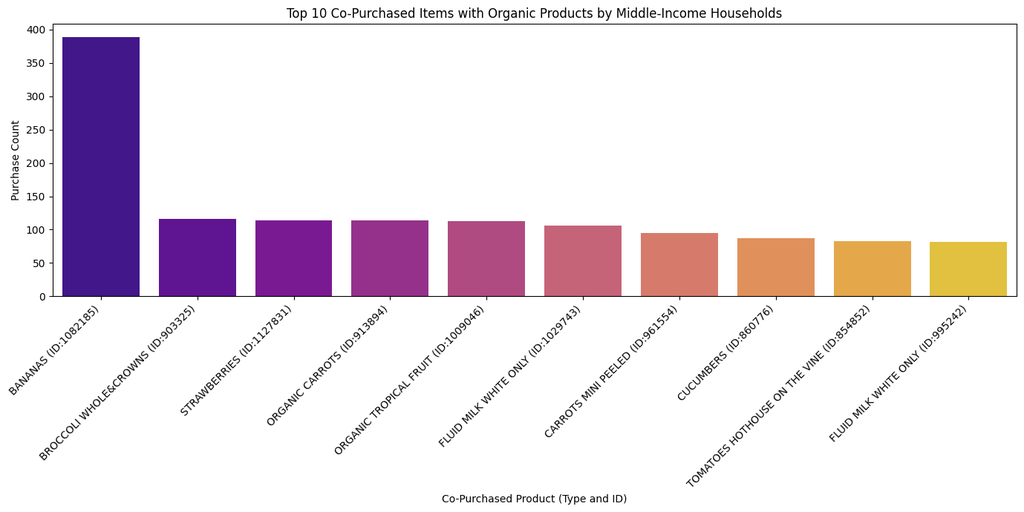

```python
plt.figure(figsize=(14, 7))
sns.barplot(x='product_label', y='count', data=top_10_co_purchased_items, palette='plasma')
plt.title('Top 10 Co-Purchased Items with Organic Products by Middle-Income Households')
plt.xlabel('Co-Purchased Product (Type and ID)')
plt.ylabel('Purchase Count')
plt.xticks(rotation=45, ha='right')
plt.tight_layout()
plt.show()
```

Overall, while seasonality affects all income segments, middle-income households appear to drive the largest share of organic sales and display the strongest mid-year spikes.

**Promotion Effectiveness**

*Promotions as a Driver of Long-Term Organic Demand*

It is important to evaluate whether promotions on organic products lead to repeat purchases, as this helps determine whether these promotions generate only short-term sales spikes or contribute to building long-term organic demand.

```python
merged_df = transactions.merge(products, on='product_id', how='left')
merged_df = merged_df.merge(households, on='household_id', how='left')
merged_df['is_promoted'] = (merged_df['retail_disc'] > 0) | (merged_df['coupon_disc'] > 0)
organic_df = merged_df[merged_df['is_organic'] == True]
total_organic_counts_by_income = organic_df.groupby('income').size()
promoted_organic_counts_by_income = organic_df[organic_df['is_promoted'] == True].groupby('income').size()
organic_df_sorted = organic_df.sort_values(by=['household_id', 'transaction_timestamp'])
first_organic_purchase_df = organic_df_sorted.groupby('household_id').first().reset_index()
merged_first_and_all_organic = organic_df.merge(first_organic_purchase_df[['household_id', 'transaction_timestamp']].rename(columns={'transaction_timestamp': 'first_organic_purchase_timestamp'}),on='household_id',how='left')
subsequent_organic_purchases_df = merged_first_and_all_organic[merged_first_and_all_organic['transaction_timestamp'] > merged_first_and_all_organic['first_organic_purchase_timestamp']]
subsequent_organic_purchase_counts = subsequent_organic_purchases_df.groupby('household_id').size().reset_index(name='subsequent_purchase_count')
household_categories_df = first_organic_purchase_df[['household_id', 'is_promoted']].copy()
household_categories_df = household_categories_df.merge(subsequent_organic_purchase_counts, on='household_id', how='left')
household_categories_df['subsequent_purchase_count'] = household_categories_df['subsequent_purchase_count'].fillna(0).astype(int)
def categorize_household(row):
    if row['is_promoted'] and row['subsequent_purchase_count'] > 0:
        return 'Promoted initial, repeated'
    elif row['is_promoted'] and row['subsequent_purchase_count'] == 0:
        return 'Promoted initial, no repeat'
    elif not row['is_promoted'] and row['subsequent_purchase_count'] > 0:
        return 'Non-promoted initial, repeated'
    else:
        return 'Non-promoted initial, no repeat'
household_categories_df['category'] = household_categories_df.apply(categorize_household, axis=1)
category_counts = household_categories_df['category'].value_counts()
total_promoted_initial = category_counts.get('Promoted initial, repeated', 0) + category_counts.get('Promoted initial, no repeat', 0)
total_non_promoted_initial = category_counts.get('Non-promoted initial, repeated', 0) + category_counts.get('Non-promoted initial, no repeat', 0)
repeat_rate_promoted = (category_counts.get('Promoted initial, repeated', 0) / total_promoted_initial) * 100 if total_promoted_initial > 0 else 0
repeat_rate_non_promoted = (category_counts.get('Non-promoted initial, repeated', 0) / total_non_promoted_initial) * 100 if total_non_promoted_initial > 0 else 0
promoted_repeated_count = category_counts.get('Promoted initial, repeated', 0)
promoted_no_repeat_count = category_counts.get('Promoted initial, no repeat', 0)
non_promoted_repeated_count = category_counts.get('Non-promoted initial, repeated', 0)
non_promoted_no_repeat_count = category_counts.get('Non-promoted initial, no repeat', 0)
```

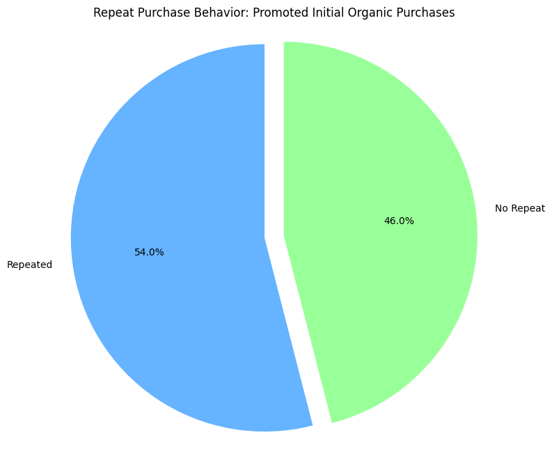

```python
import matplotlib.pyplot as plt
promoted_sizes = [promoted_repeated_count, promoted_no_repeat_count]
promoted_labels = ['Repeated', 'No Repeat']
promoted_colors = ['#66b3ff', '#99ff99'] # Example colors
promoted_explode = (0.1, 0)  # Explode the 'Repeated' slice
plt.figure(figsize=(8, 8))
plt.pie(promoted_sizes, labels=promoted_labels, colors=promoted_colors, autopct='%1.1f%%', startangle=90, explode=promoted_explode)
plt.title('Repeat Purchase Behavior: Promoted Initial Organic Purchases')
plt.axis('equal')  # Equal aspect ratio ensures that pie is drawn as a circle.
plt.show()
```

*Sales Lift Analysis of Promoted Organic Products*

Effectiveness of promotions on specific organic products to assess their impact on sales performance.

```python
promoted_organic_sales_by_product_type = organic_df[organic_df['is_promoted'] == True].groupby('product_type')['sales_value'].sum()
non_promoted_organic_sales_by_product_type = organic_df[organic_df['is_promoted'] == False].groupby('product_type')['sales_value'].sum()
organic_sales_comparison = pd.DataFrame({'Promoted Sales': promoted_organic_sales_by_product_type,'Non-Promoted Sales': non_promoted_organic_sales_by_product_type}).fillna(0)
organic_sales_comparison['Sales Lift'] = (organic_sales_comparison['Promoted Sales'] - organic_sales_comparison['Non-Promoted Sales']) / organic_sales_comparison['Non-Promoted Sales']
organic_sales_comparison = organic_sales_comparison.replace([float('inf'), -float('inf')], pd.NA)
promoted_organic_sales_by_product = organic_df[organic_df['is_promoted'] == True].groupby(['product_id', 'product_type'])['sales_value'].sum()
non_promoted_organic_sales_by_product = organic_df[organic_df['is_promoted'] == False].groupby(['product_id', 'product_type'])['sales_value'].sum()
organic_product_sales_comparison = pd.DataFrame({'Promoted Sales': promoted_organic_sales_by_product,'Non-Promoted Sales': non_promoted_organic_sales_by_product}).fillna(0)
organic_product_sales_comparison['Sales Lift'] = organic_product_sales_comparison['Promoted Sales'] - organic_product_sales_comparison['Non-Promoted Sales']
positive_sales_lift_products = organic_product_sales_comparison[organic_product_sales_comparison['Sales Lift'] > 0].sort_values(by='Sales Lift', ascending=False)
```

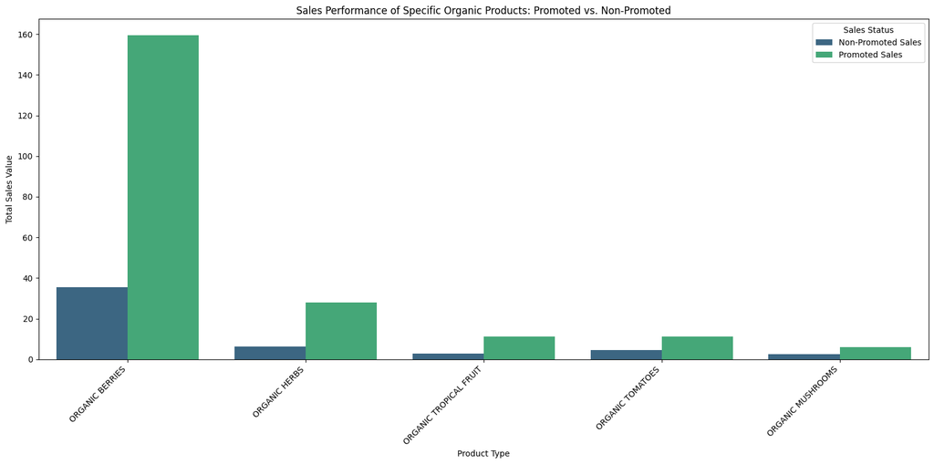

```python
specific_product_types = ['ORGANIC BERRIES','ORGANIC HERBS','ORGANIC TROPICAL FRUIT','ORGANIC TOMATOES','ORGANIC MUSHROOMS']
filtered_products_df = positive_sales_lift_products[positive_sales_lift_products.index.get_level_values('product_type').isin(specific_product_types)].reset_index()
filtered_products_df['product_label'] = filtered_products_df['product_type']
plot_df_selected = filtered_products_df.melt(id_vars=['product_id', 'product_type', 'product_label', 'Sales Lift'],value_vars=['Non-Promoted Sales', 'Promoted Sales'],var_name='Sales Type', value_name='Total Sales Value')
plot_df_selected = plot_df_selected.sort_values(by='Sales Lift', ascending=False)
plt.figure(figsize=(16, 8))
sns.barplot(x='product_label', y='Total Sales Value', hue='Sales Type', data=plot_df_selected, palette='viridis', errorbar=None)
plt.title('Sales Performance of Specific Organic Products: Promoted vs. Non-Promoted')
plt.xlabel('Product Type')
plt.ylabel('Total Sales Value')
plt.xticks(rotation=45, ha='right')
plt.legend(title='Sales Status')
plt.tight_layout()
plt.show()
```

# **Summary**

**Recommendations**

- Target middle- income level huseholds
- Time of the year: June to August to use
- Create promotions about co purchases of organic products with bananas
- Acquire first-time organic buyers